# K-Means Clustering Analysis of Protein Consumption

Amandeep Randhawa

2025-05-25

**Introduction**

This project applies **K-means clustering** to analyze protein consumption patterns across 25 European countries. The dataset includes intake percentages of various protein sources such as red meat, white meat, eggs, milk, fish, cereals, starch, nuts, and fruits & vegetables. Our objective is to uncover distinct dietary patterns and group countries into meaningful clusters based on their protein preferences.

We begin by exploring a simplified 2-variable model (RedMeat and WhiteMeat), followed by a full-dimensional clustering using all available variables. Visualizations accompany each step to support interpretation and reveal patterns.

```r
# Install packages only if not already installed
if (!require(factoextra)) install.packages("factoextra", dependencies = TRUE)
```

```r
if (!require(ggplot2)) install.packages("ggplot2")
if (!require(gridExtra)) install.packages("gridExtra")
if (!require(cluster)) install.packages("cluster")
# Load libraries
library(ggplot2)
library(gridExtra)
library(cluster)
library(factoextra)
```

```r
# Define file path (use forward slashes for portability)
file_path <- "C:/Users/amand/OneDrive/Documents/course 2 Data Mining U of G/Data mining Course 2/Assignment 2/protein.csv"

# Check if file exists
if (!file.exists(file_path)) {
  stop("Dataset file not found. Please check the file path.")
}

# Load dataset (assuming comma-separated; adjust sep = "\t" if tab-separated)
protein_data <- read.csv(file_path, header = TRUE, row.names = 1)

# Verify column names
expected_columns <- c("RedMeat", "WhiteMeat", "Eggs", "Milk", "Fish", "Cereals", "Starch", "Nuts", "Fr.Veg")
if (!all(expected_columns %in% colnames(protein_data))) {
  stop("Dataset does not contain all expected columns.")
}

# Check for missing values
if (any(is.na(protein_data))) {
  stop("Dataset contains missing values. Please handle them before proceeding.")
}

# View first few rows
head(protein_data)
```

|  | RedMeat | WhiteMeat | Eggs | Milk | Fish | Cereals | Starch | Nuts | Fr.Veg |
| --- | --- | --- | --- | --- | --- | --- | --- | --- | --- |
| Albania | 10.1 | 1.4 | 0.5 | 8.9 | 0.2 | 42.3 | 0.6 | 5.5 | 1.7 |
| Austria | 8.9 | 14.0 | 4.3 | 19.9 | 2.1 | 28.0 | 3.6 | 1.3 | 4.3 |
| Belgium | 13.5 | 9.3 | 4.1 | 17.5 | 4.5 | 26.6 | 5.7 | 2.1 | 4.0 |
| Bulgaria | 7.8 | 6.0 | 1.6 | 8.3 | 1.2 | 56.7 | 1.1 | 3.7 | 4.2 |
| Czechoslovakia | 9.7 | 11.4 | 2.8 | 12.5 | 2.0 | 34.3 | 5.0 | 1.1 | 4.0 |
| Denmark | 10.6 | 10.8 | 3.7 | 25.0 | 9.9 | 21.9 | 4.8 | 0.7 | 2.4 |

```r
# Subset RedMeat and WhiteMeat
meat_data <- protein_data[, c("RedMeat", "WhiteMeat")]

# Apply K-means clustering with k = 3
set.seed(123)
k3 <- kmeans(meat_data, centers = 3, nstart = 25)

# Add cluster assignments to data
meat_data$Cluster <- as.factor(k3$cluster)

# Print cluster assignments
print(k3$cluster)
```

```
##        Albania        Austria        Belgium       Bulgaria Czechoslovakia
##              2              3              1              2              3
##        Denmark      E Germany        Finland         France         Greece
##              3              3              2              1              2
##        Hungary        Ireland          Italy    Netherlands         Norway
##              3              1              2              3              2
##         Poland       Portugal        Romania          Spain         Sweden
##              3              2              2              2              2
##    Switzerland             UK           USSR      W Germany     Yugoslavia
##              1              1              2              3              2
```

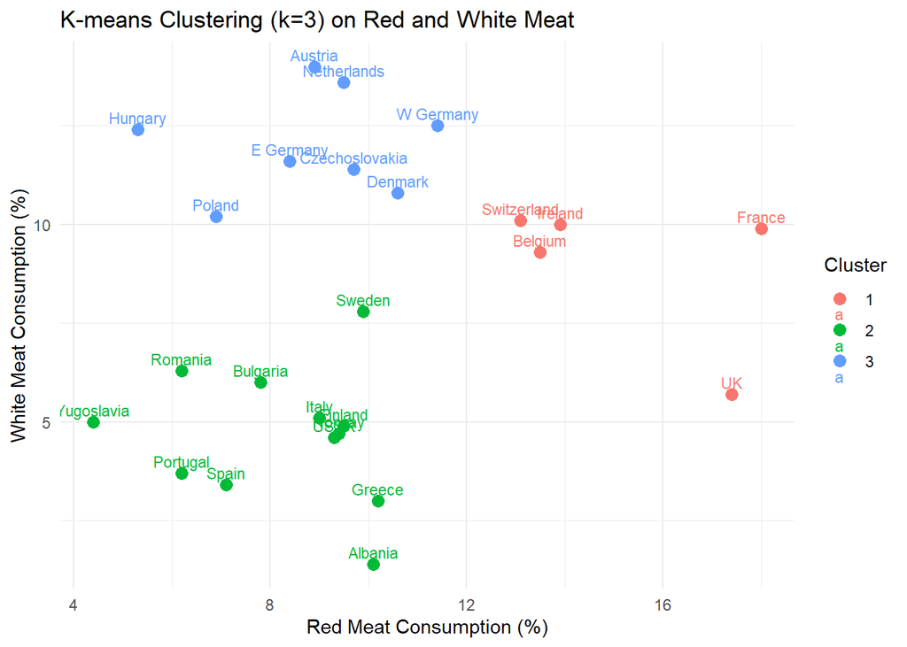

```r
# Visualize clusters
ggplot(meat_data, aes(x = RedMeat, y = WhiteMeat, color = Cluster, label = rownames(meat_data))) +
  geom_point(size = 3) +
  geom_text(vjust = -0.5, size = 3) +
  labs(title = "K-means Clustering (k=3) on Red and White Meat",
       x = "Red Meat Consumption (%)",
       y = "White Meat Consumption (%)") +
  theme_minimal()
```

Interpretation of Clustering Results

The K-means clustering results are used to understand the dietary patterns of European countries based on their protein consumption.

K-means Clustering with k=3 (RedMeat and WhiteMeat)

```r
# Normalize the data
protein_scaled <- scale(protein_data)

# Apply K-means clustering with k = 7
set.seed(123)
k7 <- kmeans(protein_scaled, centers = 7, nstart = 25)

# Add cluster assignments to original data
protein_data$Cluster <- as.factor(k7$cluster)

# Summarize cluster sizes
cat("Cluster sizes:\n")
```

```
## Cluster sizes:
```

```r
table(k7$cluster)
```

```
##
## 1 2 3 4 5 6 7
## 4 2 4 5 2 4 4
```

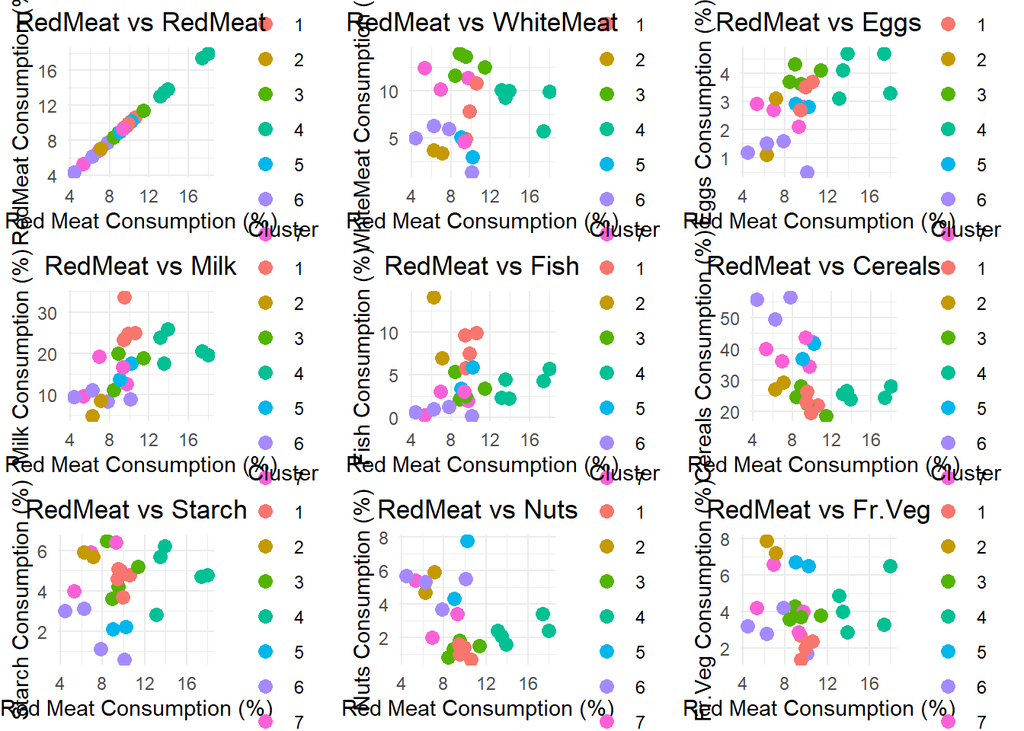

```r
# List of variables to plot against RedMeat
variables <- setdiff(colnames(protein_data), c("Cluster", "Country"))

# Generate scatter plots
plots <- list()
for (i in seq_along(variables)) {
  var <- variables[i]
  p <- ggplot(protein_data, aes_string(x = "RedMeat", y = var, color = "Cluster")) +
    geom_point(size = 3) +
    labs(title = paste("RedMeat vs", var),
         x = "Red Meat Consumption (%)",
         y = paste(var, "Consumption (%)")) +
    theme_minimal() +
    theme(plot.title = element_text(hjust = 0.5))
  plots[[i]] <- p
}
# Display plots in a 3x3 grid
grid.arrange(grobs = plots, ncol = 3)
```

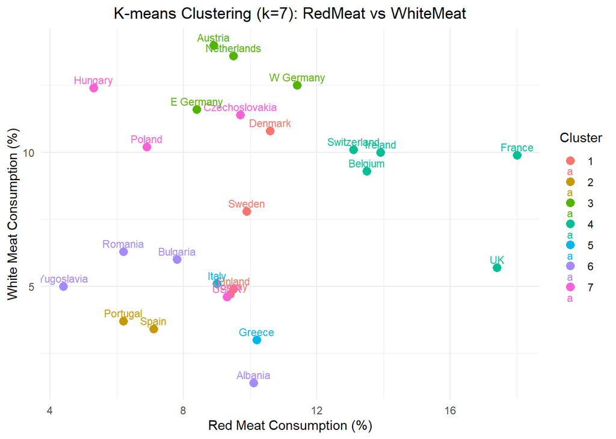

```r
ggplot(protein_data, aes(x = RedMeat, y = WhiteMeat, color = Cluster)) +
  geom_point(size = 3) +
  geom_text(aes(label = rownames(protein_data)), vjust = -0.5, size = 3) +
  labs(title = "K-means Clustering (k=7): RedMeat vs WhiteMeat",
       x = "Red Meat Consumption (%)",
       y = "White Meat Consumption (%)") +
  theme_minimal() +
  theme(plot.title = element_text(hjust = 0.5))
```

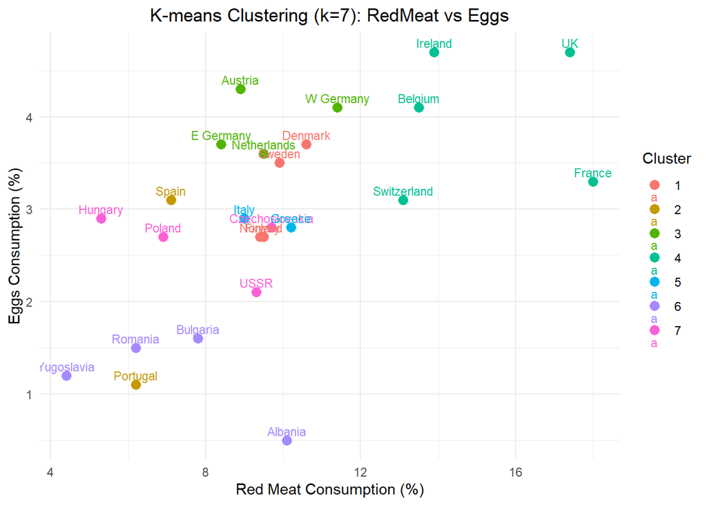

```r
ggplot(protein_data, aes(x = RedMeat, y = Eggs, color = Cluster)) +
  geom_point(size = 3) +
  geom_text(aes(label = rownames(protein_data)), vjust = -0.5, size = 3) +
  labs(title = "K-means Clustering (k=7): RedMeat vs Eggs",
       x = "Red Meat Consumption (%)",
       y = "Eggs Consumption (%)") +
  theme_minimal() +
  theme(plot.title = element_text(hjust = 0.5))
```

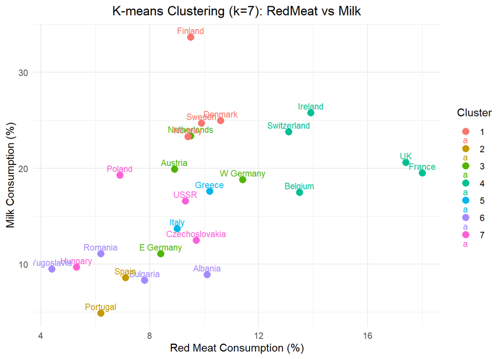

```r
ggplot(protein_data, aes(x = RedMeat, y = Milk, color = Cluster)) +
  geom_point(size = 3) +
  geom_text(aes(label = rownames(protein_data)), vjust = -0.5, size = 3) +
  labs(title = "K-means Clustering (k=7): RedMeat vs Milk",
       x = "Red Meat Consumption (%)",
       y = "Milk Consumption (%)") +
  theme_minimal() +
  theme(plot.title = element_text(hjust = 0.5))
```

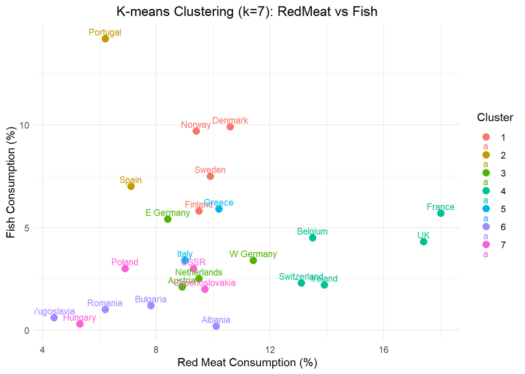

```r
ggplot(protein_data, aes(x = RedMeat, y = Fish, color = Cluster)) +
  geom_point(size = 3) +
  geom_text(aes(label = rownames(protein_data)), vjust = -0.5, size = 3) +
  labs(title = "K-means Clustering (k=7): RedMeat vs Fish",
       x = "Red Meat Consumption (%)",
       y = "Fish Consumption (%)") +
  theme_minimal() +
  theme(plot.title = element_text(hjust = 0.5))
```

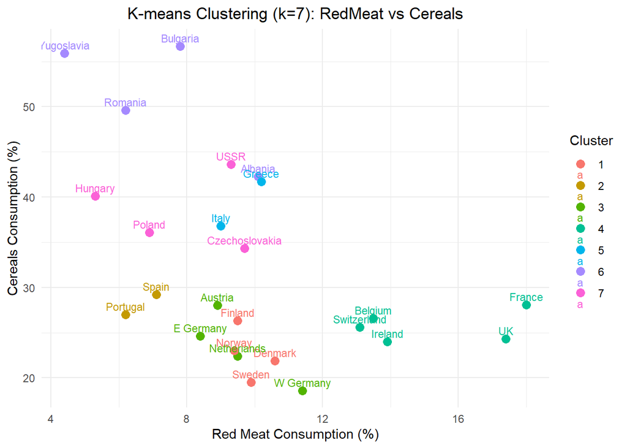

```r
ggplot(protein_data, aes(x = RedMeat, y = Cereals, color = Cluster)) +
  geom_point(size = 3) +
  geom_text(aes(label = rownames(protein_data)), vjust = -0.5, size = 3) +
  labs(title = "K-means Clustering (k=7): RedMeat vs Cereals",
       x = "Red Meat Consumption (%)",
       y = "Cereals Consumption (%)") +
  theme_minimal() +
  theme(plot.title = element_text(hjust = 0.5))
```

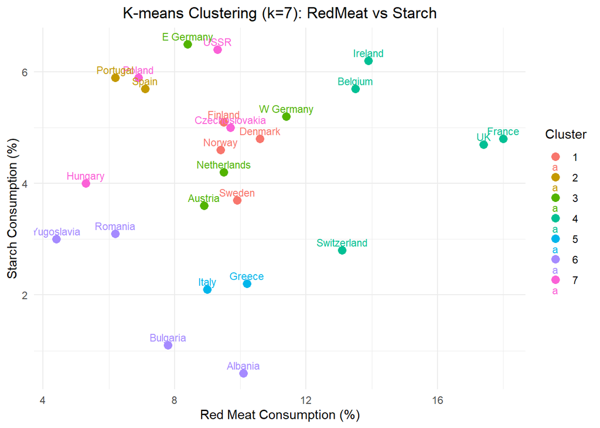

```r
ggplot(protein_data, aes(x = RedMeat, y = Starch, color = Cluster)) +
  geom_point(size = 3) +
  geom_text(aes(label = rownames(protein_data)), vjust = -0.5, size = 3) +
  labs(title = "K-means Clustering (k=7): RedMeat vs Starch",
       x = "Red Meat Consumption (%)",
       y = "Starch Consumption (%)") +
  theme_minimal() +
  theme(plot.title = element_text(hjust = 0.5))
```

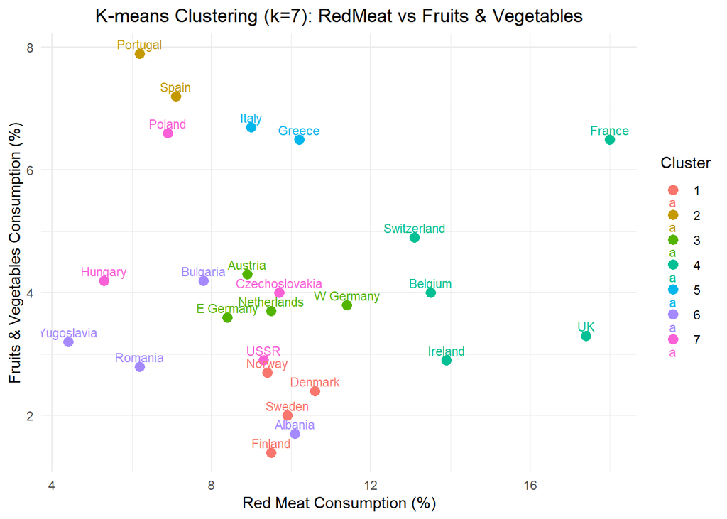

```r
ggplot(protein_data, aes(x = RedMeat, y = Fr.Veg, color = Cluster)) +
  geom_point(size = 3) +
  geom_text(aes(label = rownames(protein_data)), vjust = -0.5, size = 3) +
  labs(title = "K-means Clustering (k=7): RedMeat vs Fruits & Vegetables",
       x = "Red Meat Consumption (%)",
       y = "Fruits & Vegetables Consumption (%)") +
  theme_minimal() +
  theme(plot.title = element_text(hjust = 0.5))
```

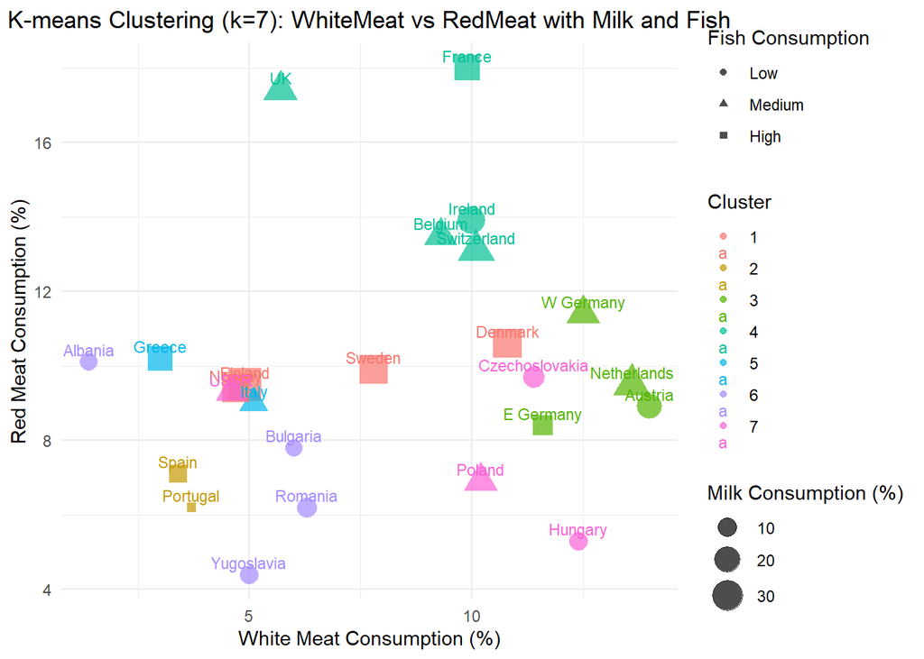

```r
# Categorize Fish consumption into 3 levels (low, medium, high) for point shapes
protein_data$Fish_Category <- cut(protein_data$Fish,
                                  breaks = quantile(protein_data$Fish, probs = c(0, 0.33, 0.66, 1)),
                                  labels = c("Low", "Medium", "High"),
                                  include.lowest = TRUE)

# Create complex scatter plot
ggplot(protein_data, aes(x = WhiteMeat, y = RedMeat, color = Cluster, size = Milk, shape = Fish_Category)) +
  geom_point(alpha = 0.7) +
  geom_text(aes(label = rownames(protein_data)), vjust = -0.5, size = 3) +
  scale_size_continuous(range = c(2, 8), name = "Milk Consumption (%)") +
  scale_shape_manual(values = c(16, 17, 15), name = "Fish Consumption") +
  labs(title = "K-means Clustering (k=7): WhiteMeat vs RedMeat with Milk and Fish",
       x = "White Meat Consumption (%)",
       y = "Red Meat Consumption (%)") +
  theme_minimal() +
  theme(plot.title = element_text(hjust = 0.5),
        legend.position = "right")
```

```r
# Add country names to the dataset
protein_data$Country <- rownames(protein_data)

# Display sorted data by cluster
View(protein_data[order(protein_data$Cluster), c("Country", "Cluster", expected_columns)])

# Summarize cluster centroids
cat("Cluster centroids (scaled):\n")
```

```
## Cluster centroids (scaled):
```

```r
print(k7$centers)
```

```
##        RedMeat  WhiteMeat        Eggs       Milk       Fish    Cereals
## 1  0.006572897 -0.2290150  0.19147892  1.3458748  1.1582546 -0.8722721
## 2 -0.949484801 -1.1764767 -0.74802044 -1.4583242  1.8562639 -0.3779572
## 3 -0.083057512  1.3613671  0.88491892  0.1671964 -0.2745013 -0.8062116
## 4  1.599006499  0.2988565  0.93413079  0.6091128 -0.1422470 -0.5948180
## 5 -0.068119111 -1.0411250 -0.07694947 -0.2057585  0.1075669  0.6380079
## 6 -0.807569986 -0.8719354 -1.55330561 -1.0783324 -1.0386379  1.7200335
## 7 -0.605901566  0.4748136 -0.27827076 -0.3640885 -0.6492221  0.5719474
##       Starch        Nuts     Fr.Veg
## 1  0.1676780 -0.95533923 -1.1148048
## 2  0.9326321  1.12203258  1.8925628
## 3  0.3665660 -0.86720831 -0.1585451
## 4  0.3451473 -0.34849486  0.1020010
## 5 -1.3010340  1.49973655  1.3659270
## 6 -1.4234267  0.99613126 -0.6436044
## 7  0.6419495 -0.04884971  0.1602082
```

**Conclusion**

Through K-means clustering, we identified meaningful dietary clusters among European countries.

- The **3-cluster solution** based on *RedMeat* and *WhiteMeat* highlighted three distinct consumption behaviors, with Western Europe leaning toward red meat, Southern and Eastern countries showing moderate intake, and Central/Northern Europe displaying a balance.
- The **7-cluster solution** using all variables revealed more nuanced groupings, capturing differences in fish, milk, cereal, and fruit/vegetable consumption.
- Advanced scatter plots provided layered insights, such as the relationship between milk and fish intake relative to meat consumption.

This analysis demonstrates how unsupervised learning techniques like K-means can segment populations based on real-world behaviors, offering valuable insights for public health, food policy, and market segmentation.